# Seventh Week: Generalized Linear Models

Murder or suicide

Kimia Hamidieh

> با توجه به سوالات مرگ و میر در آمریکا به سوالات زیر پاسخ دهید.

# سوال ۱

۱. از میان متغیرهای داده مرگ و میر یک زیرمجموعه ایی بدون حشو در نظر بگیرید. ماتریس همبستگی متغیرهای مختلف را به دست آورده و سپس رسم نمایید. علاوه بر این نمودار پراکنش متغیرهای انتخاب شده را همزمان نسبت به هم رسم نمایید.

ستون هایی که معنای مشابهی دارند و یا واضحاً به هم مربوطند (مانند انواع ستون های مربوط به سال، نژاد و …) را حذف می کنیم. همچنین ستون های PlaceOfInjury به علت مشابه بودن با ActivityCode، CurrentDataYear و Id و Icd10Code (به علت موجود نبودن توضیحات مربوط به آن در داک داده شده) نیز حذف شده اند.

```r
ms_data %>%
  select(-c(Id, AgeType, AgeSubstitutionFlag, AgeRecode12, AgeRecode27, AgeRecode52,
            CurrentDataYear, CauseRecode358, CauseRecode113, CauseRecode39, InfantCauseRecode130,
            NumberOfEntityAxisConditions, NumberOfRecordAxisConditions,
            Race, RaceRecode5, BridgedRaceFlag, RaceImputationFlag,
            HispanicOrigin, HispanicOriginRaceRecode,
            PlaceOfInjury, # similar to ActivityCode
            Icd10Code)) -> ms # couldn't be found in docs
```

می دانیم ماتریس correlation روش مناسبی برای بررسی ارتباط متغیرها با هم نیست چرا که تنها مربوط بودن خطی دو متغیر به هم پیوسته را می دهد. اما به هر حال در این جا با توجه به صورت سوال به عنوان روشی اولیه برای حدس متغیرهای مربوط به ستون علت مرگ ارائه شده است. همان طور که از ماتریس correlation پیوست شده (pdf) دیده می شود، می توان حدس هایی برای متغیرهای مربوطه زد که مشخص شده اند.

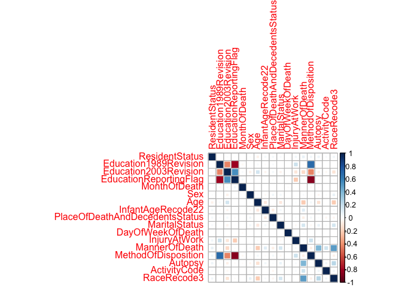

```r
ms %>%
  mutate(Sex = as.numeric(as.factor(Sex))) %>%
  mutate(MaritalStatus = as.numeric(as.factor(MaritalStatus))) %>%
  mutate(InjuryAtWork = as.numeric(as.factor(InjuryAtWork))) %>%
  mutate(MethodOfDisposition = as.numeric(as.factor(MethodOfDisposition))) %>%
  mutate(Autopsy = as.numeric(as.factor(Autopsy))) %>%
  as.matrix() -> ms_numeric

ms_cors = rcorr(ms_numeric)
cor_mat = ms_cors$r
cor_pvals = ms_cors$P

corrplot(cor_mat, p.mat = cor_pvals, method = "square", insig = "blank")
```

```r
# scatterplotMatrix(x = ms_numeric, formula = MannerOfDeath ~ .)
```

# سوال ۲

۲. اثر هر یک از متغیرهای جنسیت، نژاد،آموزش، سن و نحوه تدفین را بر مرگ یا خودکشی ارزیابی کنید.

برای بررسی اثر هر یک از متغیرها، می توان از chi-squared test of independency استفاده کرد که برای متغیرهای categorial به کار می رود. (برای متغیر آموزش، می توان همان طور که در سوال بعد، مقیاس یکسان و پیوسته ای برای آن ارائه شده است، استفاده کرد که در این صورت می توان از t-test استفاده کرد. ولی در این جا با متغیرهای categorial ِ آموزش، برای هر دسته به صورت جدا، نشان داده شده که میزان آموزش موثر است. که اگر از روش اول استفاده می کردیم نیز همین نتیجه به دست می امد.

با توجه به p-value های به دست آمده برای این تست ها می توان به این نتیجه رسید که همگی این متغیرها موثرند و باید در مدل باشند.

همچنین برای مدل بهتر در قسمت بعد، تاثیر پارامترهایی که در سوال قبل به نظر موثر آمده بودند را با استفاده از همان تست، به دست آمده و نهایتاً در متغیرهای مدل قسمت بعد قرار داده شده اند.

```r
prop.test(table(ms_data$MannerOfDeath, ms_data$Sex), correct = FALSE)
```

```
##
##  2-sample test for equality of proportions without continuity
##  correction
##
## data:  table(ms_data$MannerOfDeath, ms_data$Sex)
## X-squared = 24.151, df = 1, p-value = 8.906e-07
## alternative hypothesis: two.sided
## 95 percent confidence interval:
##  0.01124674 0.02583381
## sample estimates:
##    prop 1    prop 2
## 0.2266163 0.2080760
```

```r
chisq.test(table(ms_data$MannerOfDeath, ms_data$RaceRecode3))
```

```
##
##  Pearson's Chi-squared test
##
## data:  table(ms_data$MannerOfDeath, ms_data$RaceRecode3)
## X-squared = 15243, df = 2, p-value < 2.2e-16
```

```r
chisq.test(table(ms_data$MannerOfDeath, ms_data$AgeRecode12))
```

```
##
##  Pearson's Chi-squared test
##
## data:  table(ms_data$MannerOfDeath, ms_data$AgeRecode12)
## X-squared = 6365.9, df = 11, p-value < 2.2e-16
```

```r
chisq.test(table(ms_data$MannerOfDeath, ms_data$MethodOfDisposition))
```

```
##
##  Pearson's Chi-squared test
##
## data:  table(ms_data$MannerOfDeath, ms_data$MethodOfDisposition)
## X-squared = 4460.4, df = 6, p-value < 2.2e-16
```

```r
ms_data %>% filter(EducationReportingFlag == 0) %>% select(MannerOfDeath, Education1989Revision) -> ms_edu1998
ms_data %>% filter(EducationReportingFlag == 1) %>% select(MannerOfDeath, Education2003Revision) -> ms_edu2003
chisq.test(table(ms_edu1998$MannerOfDeath, ms_edu1998$Education1989Revision))
```

```
##
##  Pearson's Chi-squared test
##
## data:  table(ms_edu1998$MannerOfDeath, ms_edu1998$Education1989Revision)
## X-squared = 431.57, df = 18, p-value < 2.2e-16
```

```r
chisq.test(table(ms_edu2003$MannerOfDeath, ms_edu2003$Education2003Revision))
```

```
##
##  Pearson's Chi-squared test
##
## data:  table(ms_edu2003$MannerOfDeath, ms_edu2003$Education2003Revision)
## X-squared = 3552.8, df = 8, p-value < 2.2e-16
```

```r
# other vars
chisq.test(table(ms_data$MannerOfDeath, ms_data$Autopsy))
```

```
##
##  Pearson's Chi-squared test
##
## data:  table(ms_data$MannerOfDeath, ms_data$Autopsy)
## X-squared = 9644.2, df = 2, p-value < 2.2e-16
```

```r
chisq.test(table(ms_data$MannerOfDeath, ms_data$ActivityCode))
```

```
##
##  Pearson's Chi-squared test
##
## data:  table(ms_data$MannerOfDeath, ms_data$ActivityCode)
## X-squared = 1654.5, df = 6, p-value < 2.2e-16
```

```r
chisq.test(table(ms_data$MannerOfDeath, ms_data$MaritalStatus))
```

```
##
##  Pearson's Chi-squared test
##
## data:  table(ms_data$MannerOfDeath, ms_data$MaritalStatus)
## X-squared = 4651.5, df = 4, p-value < 2.2e-16
```

# سوال ۳

۳. با استفاده از مدل رگرسیون لاجستیک یک مدل به داده ها برازش دهید و سپس آن را نقص یابی کنید.

```r
ms %>%
  mutate(Education = ifelse(EducationReportingFlag, Education2003Revision/max(Education2003Revision), Education1989Revision/max(Education1989Revision))) %>%
  select(c(MannerOfDeath, Education,
           Sex, Age, PlaceOfDeathAndDecedentsStatus, MethodOfDisposition, RaceRecode3,
           Autopsy,
           # ActivityCode,
           MaritalStatus)) %>%
  mutate(PlaceOfDeathAndDecedentsStatus = as.factor(PlaceOfDeathAndDecedentsStatus)) %>%
  mutate(RaceRecode3 = as.factor(RaceRecode3)) %>%
  # mutate(ActivityCode = as.factor(ActivityCode)) %>%
  mutate(MannerOfDeath = as.factor(MannerOfDeath - 2)) -> ms_clean

# ActivityCode1                    1.066e+01  9.267e+01   0.115 0.908406
# ActivityCode2                    1.083e-01  1.530e+02   0.001 0.999435
# ActivityCode4                    1.111e+01  9.267e+01   0.120 0.904571
# ActivityCode8                    1.021e+01  9.267e+01   0.110 0.912232
# ActivityCode9                    1.033e+01  9.266e+01   0.111 0.911223
# ActivityCode99                   1.337e+01  9.267e+01   0.144 0.885280

glm_model = glm(MannerOfDeath ~ ., data = ms_clean, family = "binomial")
summary(glm_model)
```

```
##
## Call:
## glm(formula = MannerOfDeath ~ ., family = "binomial", data = ms_clean)
##
## Deviance Residuals:
##     Min       1Q   Median       3Q      Max
## -2.6623  -0.5739  -0.1654   0.3899   4.0245
##
## Coefficients:
##                                   Estimate Std. Error z value Pr(>|z|)
## (Intercept)                     -2.1399717  0.0881241 -24.284  < 2e-16 ***
## Education                       -1.8851085  0.0751521 -25.084  < 2e-16 ***
## SexM                            -0.2980235  0.0292987 -10.172  < 2e-16 ***
## Age                             -0.0034944  0.0007147  -4.889 1.01e-06 ***
## PlaceOfDeathAndDecedentsStatus2  0.1929404  0.0482583   3.998 6.39e-05 ***
## PlaceOfDeathAndDecedentsStatus3 -0.4011341  0.0932186  -4.303 1.68e-05 ***
## PlaceOfDeathAndDecedentsStatus4 -1.5085471  0.0428289 -35.223  < 2e-16 ***
## PlaceOfDeathAndDecedentsStatus5  1.1843214  0.2244433   5.277 1.32e-07 ***
## PlaceOfDeathAndDecedentsStatus6  0.7779753  0.1904275   4.085 4.40e-05 ***
## PlaceOfDeathAndDecedentsStatus7 -0.5144275  0.0422549 -12.174  < 2e-16 ***
## PlaceOfDeathAndDecedentsStatus9 -0.6475245  0.2312802  -2.800  0.00511 **
## MethodOfDispositionC            -0.7714680  0.0272865 -28.273  < 2e-16 ***
## MethodOfDispositionD            -1.3448899  0.3004531  -4.476 7.60e-06 ***
## MethodOfDispositionE            -0.1682749  0.1721592  -0.977  0.32835
## MethodOfDispositionO             0.1771096  0.1754804   1.009  0.31284
## MethodOfDispositionR            -0.1720130  0.0661261  -2.601  0.00929 **
## MethodOfDispositionU            -1.1194552  0.0470386 -23.799  < 2e-16 ***
## RaceRecode32                     0.3528653  0.0581989   6.063 1.34e-09 ***
## RaceRecode33                     1.9749049  0.0317737  62.155  < 2e-16 ***
## AutopsyU                         2.2879097  0.1068851  21.405  < 2e-16 ***
## AutopsyY                         3.4179363  0.0615993  55.487  < 2e-16 ***
## MaritalStatusM                  -0.2133696  0.0382533  -5.578 2.44e-08 ***
## MaritalStatusS                   0.3202654  0.0374061   8.562  < 2e-16 ***
## MaritalStatusU                   1.1396719  0.1174116   9.707  < 2e-16 ***
## MaritalStatusW                   0.1055176  0.0644354   1.638  0.10151
## ---
## Signif. codes:  0 '***' 0.001 '**' 0.01 '*' 0.05 '.' 0.1 ' ' 1
##
## (Dispersion parameter for binomial family taken to be 1)
##
##     Null deviance: 71216  on 59978  degrees of freedom
## Residual deviance: 42032  on 59954  degrees of freedom
## AIC: 42082
##
## Number of Fisher Scoring iterations: 7
```

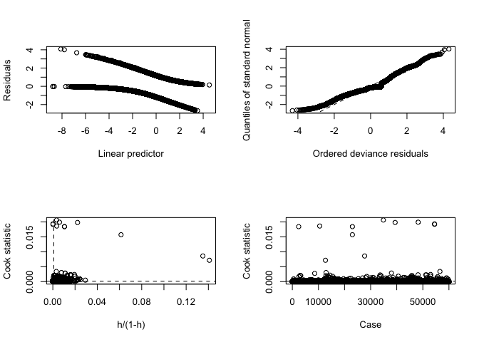

```r
library("boot")
glm.diag.plots(glm_model, glmdiag = glm.diag(glm_model))
```

# سوال ۴

۴. با استفاده از سه نمودار خروجی مدل را نسبت به داده واقعی ارزیابی کنید.

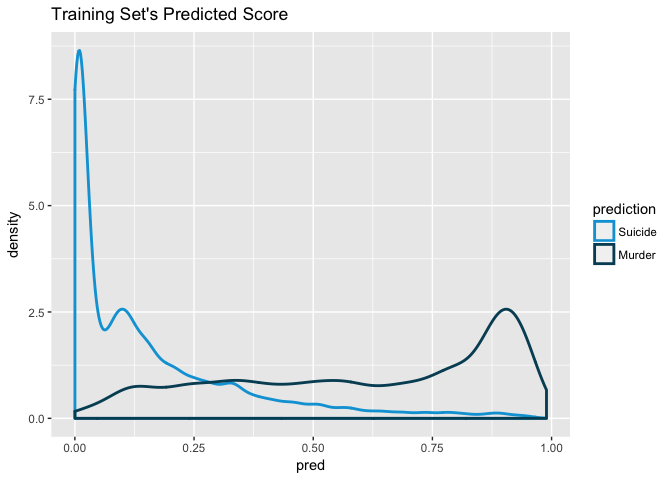

```r
ms_preds = ms_clean %>% mutate(pred = predict(glm_model, type = 'response'))

# 0: suicide  1: murder
ggplot(ms_preds, aes(pred, color = as.factor(MannerOfDeath))) +
  geom_density(size = 1) +
  ggtitle("Training Set's Predicted Score") +
  scale_color_economist(name = "prediction", labels = c("Suicide", "Murder"))
```

با توجه به این نمودار، نمونه های مربوط به خودکشی، نسبتاً خوب پیش بینی می شوند چرا که تعداد بسیار کمی از آن ها مقدار نزدیک به ۱ دارد. (نسبت به تعداد کل) همچنین تعداد زیادی از آن ها مقدار پیش بینی شده برای آن ها بسیار نزدیک به صفر به دست آمده است. اما برای قتل، مدل نتوانسته است پیش بینی نسبتاً خوبی ارائه دهد چرا که تقریباً ۱/۳ قتل ها (اگر پارامتری که برای تشخیص بین ۰ و ۱ داریم را ۰.۵ در نظر گیریم) در قسمت خودکشی قرار خواهند گرفت. همچنین این نمودار در بازه ی ۰.۲۵ تا ۰.۷۵ تقریباً یونیفرم است. در بازه ی ۰ تا ۰.۳ نیز تداخل این نمودارها نسبتاً زیاد است (به علت درست پیش بینی نشدن قتل)

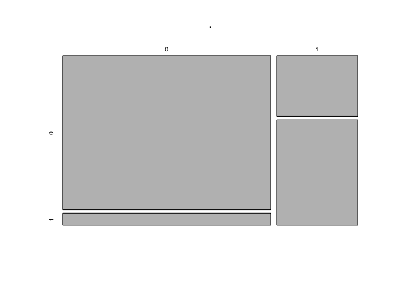

```r
table(ms_preds$MannerOfDeath, ifelse(fitted(glm_model) > 0.5, 1, 0)) %>% plot()
```

با توجه به این نمودار، محور عمودی پیش بینی ما (با پارامتر ۰.۵) و محور افقی مقدار واقعی است. یعنی مستطیل بالا سمت راست، مقادیر قتل هایی که خودکشی پیش بینی شده اند را نشان می دهد که از پایین سمت چپ که خودکشی هایی که قتل پیش بینی شده اند بیشتر است. که اگر پارامترمان را در نمودار قبلی ۰.۵ در نظر بگیریم، این مستطیل ها هر یک متناظر با قسمتی از نمودار قبلی اند. (مثلاً نمودار مربوط به خودکشی های با مقدار predict بیشتر از ۰.۵، معادل مستطیل پایین چپ اند.)

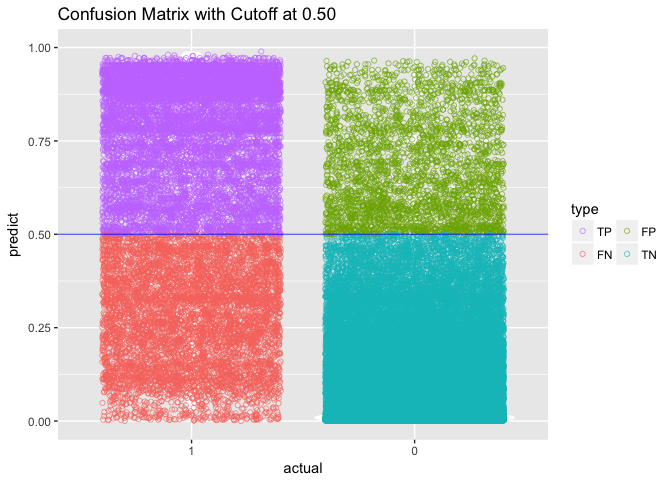

```r
ms_info = ConfusionMatrixInfo(data = ms_preds, predict = "pred",
                              actual = "MannerOfDeath", cutoff = .5)
ms_info$plot
```

# سوال ۵

۵. ابتدا ۲۰ درصد داده را به صورت تصادفی به عنوان تست در نظر بگیرید. مدل را با استفاده از ۸۰ درصد باقی مانده برازش دهید. با استفاده از پارامتر قطع ۰.۵ نتایج را برای داده تست پیش بینی کنید. سپس کمیت های زیر را محاسبه کنید.

- P: positive samples
- N: negative samples
- TP: true positive TP (eqv. with hit)
- TN: true negative (eqv. with correct rejection)
- FP: false positive (eqv. with false alarm, Type I error)
- FN: false negative (eqv. with miss, Type II error)
- Accuracy (ACC) ACC = (TP+TN)/(P+T)
- False positive rate (FPR): 1- TN/N
- True positive rate (TPR): TP/P

مشابه آنچه در کلاس گفته شد نمایشی از چهار کمیت TN, TP,FP,FN به همراه داده ها رسم نمایید.

```r
index = sample(x = 1:nrow(ms_clean), size = 0.8 * nrow(ms_clean), replace = F)
train = ms_clean[index,]
test =  ms_clean[-index,]

model_train = glm(MannerOfDeath ~ ., data = train, family = "binomial")

train$prediction = predict(model_train, newdata = train, type = "response")
test$prediction  = predict(model_train, newdata = test , type = "response")

test$binpred = ifelse(test$prediction > 0.5, 1, 0)

P = length(which(test$binpred == 1))
N = length(which(test$binpred == 0))

tconf <- with(test, table("Prediction" = binpred, "Reference" = MannerOfDeath))
TP = tconf[1, 1]
FP = tconf[1, 2]
FN = tconf[2, 1]
TN = tconf[2, 2]

ACC = (TP + TN) / (P + N)
FPR = 1 - TN / N
TPR = TP / P

print(c("P:", P, "N:", N))
```

```
## [1] "P:"   "2667" "N:"   "9329"
```

```r
tconf
```

```
##           Reference
## Prediction    0    1
##          0 8099 1230
##          1  611 2056
```

```r
print(c("TP:", TP, "TN:", TN, "FP:", FP, "TN:", FN))
```

```
## [1] "TP:"  "8099" "TN:"  "2056" "FP:"  "1230" "TN:"  "611"
```

```r
print(c("ACC:", ACC, "FPR:", FPR, "TPR:", TPR))
```

```
## [1] "ACC:"              "0.846532177392464" "FPR:"
## [4] "0.779611962696966" "TPR:"              "3.03674540682415"
```

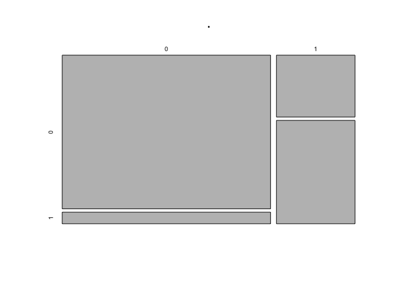

```r
table(test$MannerOfDeath, test$binpred) %>% plot()
```

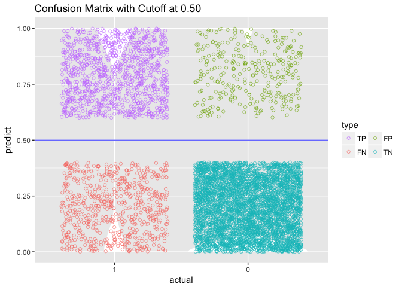

```r
cm_info = ConfusionMatrixInfo(data = test, predict = "binpred",
                              actual = "MannerOfDeath", cutoff = .5)
cm_info$plot
```

# سوال ۶

۶. نمودار صحت مدل (accuracy) را بر حسب مقادیر مختلف قطع برای داده تست رسم نمایید. کدام پارامتر قطع بالاترین صحت را در پیش بینی داراست؟

با توجه به نمودار کشیده شده برای accuracy برای مقادیر مختلف پارامتر قطع، می توان دید که accuracy دیتای test (و نیز دیتای train) بیشترین مقدار را در cutoff = 0.48 دارد. که این را نیز با نمودارهای قبلی به این دلیل می توان توجیه کرد که با پارامتر قطع ۰.۵، مقدار FN بیشتر از FP بوده و با نزدیک کردن cutoff به صفر جمع این دو مقدار مینیمم شده است.

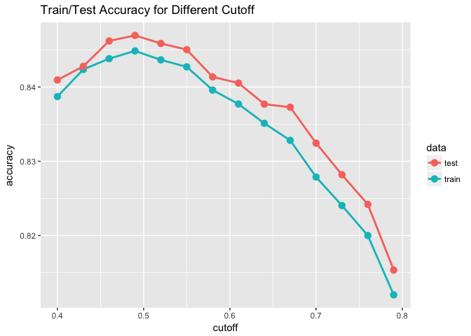

```r
accuracy_info = AccuracyCutoffInfo(train = train, test = test,
                                   predict = "prediction", actual = "MannerOfDeath")
accuracy_info$plot
```

# سوال ۷

۷. نمودار ROC را برای داده های قسمت قبل رسم نمایید. همچنین نقطه مربوط به بهترین پارامتر قطع را مشخص نمایید.

```r
cost_fp = 100
cost_fn = 200
roc_info = ROCInfo(data = cm_info$data, predict = "predict",
                    actual = "actual", cost.fp = cost_fp, cost.fn = cost_fn)
```

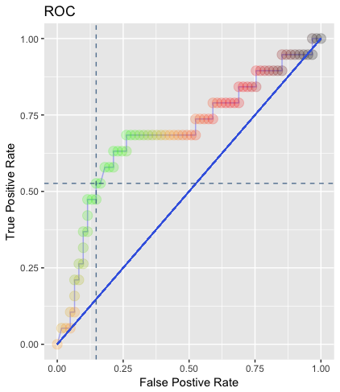

```r
roc_info$roc_plot
```

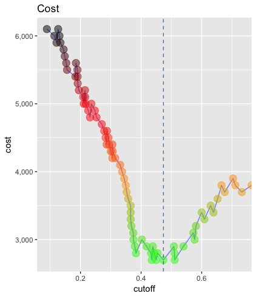

```r
roc_info$cost_plot
```

با توجه به این که نمودارها در مارک داون ران نشدند، از عکس آن ها که از اسکریپت پیوست شده به دست آمده است، استفاده شده.

# سوال ۸

۸. با قرار دادن کمیت nfolds = 5 و با استفاده از H20 مدل مساله را بسازید و نتیجه حاصل را ارزیابی کنید.

```r
library(h2o)
h2o.init()
```

```
##  Connection successful!
##
## R is connected to the H2O cluster:
##     H2O cluster uptime:         1 hours 10 minutes
##     H2O cluster version:        3.16.0.2
##     H2O cluster version age:    4 months and 29 days !!!
##     H2O cluster name:           H2O_started_from_R_Kimia_nnk105
##     H2O cluster total nodes:    1
##     H2O cluster total memory:   0.72 GB
##     H2O cluster total cores:    4
##     H2O cluster allowed cores:  4
##     H2O cluster healthy:        TRUE
##     H2O Connection ip:          localhost
##     H2O Connection port:        54321
##     H2O Connection proxy:       NA
##     H2O Internal Security:      FALSE
##     H2O API Extensions:         XGBoost, Algos, AutoML, Core V3, Core V4
##     R Version:                  R version 3.4.1 (2017-06-30)
```

```r
ms_clean %>%
  mutate(MaritalStatus = as.factor(MaritalStatus)) %>%
  mutate(MethodOfDisposition = as.factor(MethodOfDisposition)) %>%
  mutate(Autopsy = as.factor(Autopsy)) %>%
  mutate(Sex = as.factor(Sex)) -> ms_h2o

hms = as.h2o(ms_h2o)
chglm = h2o.glm(y = "MannerOfDeath", x = c("Education", "Sex", "Age", "PlaceOfDeathAndDecedentsStatus",
                                           "MethodOfDisposition", "RaceRecode3",
                                           "Autopsy", "MaritalStatus"),
                training_frame = hms, family = "binomial", nfolds = 5, compute_p_values=TRUE, lambda = 0)
summary(chglm)
```

```
## Model Details:
## ==============
##
## H2OBinomialModel: glm
## Model Key:  GLM_model_R_1524946967972_110
## GLM Model: summary
##     family  link regularization number_of_predictors_total
## 1 binomial logit           None                         24
##   number_of_active_predictors number_of_iterations training_frame
## 1                          24                    6         ms_h2o
##
## H2OBinomialMetrics: glm
## ** Reported on training data. **
##
## MSE:  0.1107706
## RMSE:  0.3328222
## LogLoss:  0.350387
## Mean Per-Class Error:  0.1909159
## AUC:  0.8986443
## Gini:  0.7972886
## R^2:  0.4514569
## Residual Deviance:  42031.72
## AIC:  42081.72
##
## Confusion Matrix (vertical: actual; across: predicted) for F1-optimal threshold:
##            0     1    Error          Rate
## 0      37165  5974 0.138483   =5974/43139
## 1       4098 12742 0.243349   =4098/16840
## Totals 41263 18716 0.167925  =10072/59979
##
## Maximum Metrics: Maximum metrics at their respective thresholds
##                         metric threshold    value idx
## 1                       max f1  0.351429 0.716729 212
## 2                       max f2  0.195052 0.791462 278
## 3                 max f0point5  0.557179 0.746368 140
## 4                 max accuracy  0.490774 0.845479 164
## 5                max precision  0.989303 1.000000   0
## 6                   max recall  0.001371 1.000000 399
## 7              max specificity  0.989303 1.000000   0
## 8             max absolute_mcc  0.450182 0.603951 177
```

[output cut: 91 more lines]

```
##                              names coefficients sign
## 1                        Autopsy.Y     3.417933  POS
## 2                        Autopsy.U     2.287906  POS
## 3                    RaceRecode3.3     1.974905  POS
## 4 PlaceOfDeathAndDecedentsStatus.4     1.508547  NEG
## 5            MethodOfDisposition.D     1.344890  NEG
##
## ---
##                               names coefficients sign
## 19 PlaceOfDeathAndDecedentsStatus.2     0.192940  POS
## 20            MethodOfDisposition.O     0.177110  POS
## 21            MethodOfDisposition.R     0.172013  NEG
## 22            MethodOfDisposition.E     0.168275  NEG
## 23                  MaritalStatus.W     0.105518  POS
## 24                              Age     0.087704  NEG
```

```r
h2o.r2(chglm)
```

```
## [1] 0.4514569
```

```r
chglm@model$coefficients_table
```

```
## Coefficients: glm coefficients
##                              names coefficients std_error    z_value
## 1                        Intercept    -2.139968  0.088124 -24.283574
## 2 PlaceOfDeathAndDecedentsStatus.2     0.192940  0.048258   3.998076
## 3 PlaceOfDeathAndDecedentsStatus.3    -0.401134  0.093219  -4.303156
## 4 PlaceOfDeathAndDecedentsStatus.4    -1.508547  0.042829 -35.222639
## 5 PlaceOfDeathAndDecedentsStatus.5     1.184321  0.224443   5.276706
##    p_value standardized_coefficients
## 1 0.000000                 -3.009924
## 2 0.000064                  0.192940
## 3 0.000017                 -0.401134
## 4 0.000000                 -1.508547
## 5 0.000000                  1.184321
##
## ---
##            names coefficients std_error    z_value  p_value
## 20     Autopsy.Y     3.417933  0.061599  55.486576 0.000000
## 21 RaceRecode3.2     0.352865  0.058199   6.063093 0.000000
## 22 RaceRecode3.3     1.974905  0.031774  62.155298 0.000000
## 23         Sex.M    -0.298024  0.029299 -10.171905 0.000000
## 24     Education    -1.885108  0.075152 -25.083919 0.000000
## 25           Age    -0.003494  0.000715  -4.889134 0.000001
##    standardized_coefficients
## 20                  3.417933
## 21                  0.352865
## 22                  1.974905
## 23                 -0.298024
## 24                 -0.375336
## 25                 -0.087704
```

در استفاده از pseoudo R^2، می توان گفت که اگر از نوع McFadden باشد و بین ۰.۲ تا ۰.۴، داده ها نسبتاً خوب فیت شده اند. با توجه به مقدار به دست آمده برای R-squared، می توان گفت مدل ارائه شده کاملاً این شرط را دارا نیست ولی تا حد خوبی مطلوب است. با توجه به مقادیر به دست آمده برای p-valueها، نمی توان گفت پارامترهای به دست آمده کاملاُ significant هستند، ولی مدل در اکثر مواقع خوب جواب می دهد.

# سوال ۹

۹. آیا ما میتوانیم سرویسی به قضات ارایه کنیم تا با استفاده از اطلاعات مرگ بتوانند موارد مشکوک به قتل را از خودکشی تفکیک دهند؟

مدل هایی که ما به دست آورده ایم، چه با تابع glm ساده و چه با استفاده از کتاب خانه ی h2o، خطای نسبتاً زیادی دارند. که البته شاید بتوان با داده ی train بیشتر این خطا را کم کرد. ولی به نظر من، این خطا ناشی از پارامترهایی است که احتمالاً در تشخیص قتل یا خودکشی تاثیر داشته و در این داده آورده نشده است. چون این سوال برای تشخیص باید پارامترهای انسانی مثل شخصیت فرد، وضعیت روحی او در زمان های مختلف، شخصیت و رفتار اطرافیان و … را در نظر گرفت. که باز اندازه گیری هر یک از این کمیت ها برای افراد قابل بررسی نیست. قاضی در واقع برای بررسی هر کیس، تعدادی از این کمیت ها را در نظر گرفته و روی آن ها تمرکز می کند. همچنین مسئله ی پیچیده ای مانند قتل، به پارامترهای بسیار زیادی و در نتیجه داده ی بزرگ احتیاج دارد. اما باز خودکشی فاکتورهای نسبتاً مشخص تری دارد و به همین علت مدل ها راحت تر بتوانند خودکشی نبودن یک کیس را تشخیص دهند. در هر صورت تعداد پارامترهای مسئله بسیار زیاد بوده و حتی ممکن است بعضی از آن ها را در نظر نگیریم. ابزارهایی که به این روش تولید می شود، تنها می تواند به قاضی کمک کند و پیش زمینه به او بدهد.